# Case 12

Brink

11/28/2022

```r
library(ggplot2)
library(readr)
library(knitr)
library(dplyr)
library(forcats)
library(downloader)
library(corrplot)
library(tidyquant)
library(timetk)
library(dygraphs)
library(scales)
library(tidyverse)
library(sf)
library(USAboundaries)
library(maps)
library(ggsflabel)
library(devtools)
library(remotes)
library(stringr)
library(leaflet)
library(mapview)
library(riem)
library(stringi)
library(stringr)
library(gifski)
library(gganimate)
library(gridExtra)
library(viridis)
avocado <- read_csv("avocado.csv")
```

```
## ──────────────────────────────────────────────────────── Delimiter: "," chr
## (2): type, region dbl (11): ...1, AveragePrice, Total Volume, 4046, 4225, 4770,
## Total Bags, S... date (1): Date
```

```r
head(avocado)
```

```
## # A tibble: 6 × 14
##    ...1 Date       AveragePrice `Total Volume` `4046` `4225` `4770` `Total Bags`
##   <dbl> <date>            <dbl>          <dbl>  <dbl>  <dbl>  <dbl>        <dbl>
## 1     0 2015-12-27         1.33         64237.  1037. 5.45e4   48.2        8697.
## 2     1 2015-12-20         1.35         54877.   674. 4.46e4   58.3        9506.
## 3     2 2015-12-13         0.93        118220.   795. 1.09e5  130.         8145.
## 4     3 2015-12-06         1.08         78992.  1132  7.20e4   72.6        5811.
## 5     4 2015-11-29         1.28         51040.   941. 4.38e4   75.8        6184.
## 6     5 2015-11-22         1.26         55980.  1184. 4.81e4   43.6        6684.
## # … with 6 more variables: `Small Bags` <dbl>, `Large Bags` <dbl>,
## #   `XLarge Bags` <dbl>, type <chr>, year <dbl>, region <chr>
```

```r
tail(avocado)
```

```
## # A tibble: 6 × 14
##    ...1 Date       AveragePrice `Total Volume` `4046` `4225` `4770` `Total Bags`
##   <dbl> <date>            <dbl>          <dbl>  <dbl>  <dbl>  <dbl>        <dbl>
## 1     6 2018-02-11         1.57         15986.  1924.  1368.     0        12694.
## 2     7 2018-02-04         1.63         17075.  2047.  1529.     0        13499.
## 3     8 2018-01-28         1.71         13888.  1192.  3432.     0         9265.
## 4     9 2018-01-21         1.87         13767.  1192.  2453.   728.        9394.
## 5    10 2018-01-14         1.93         16205.  1528.  2981.   727.       10970.
## 6    11 2018-01-07         1.62         17490.  2895.  2356.   225.       12014.
## # … with 6 more variables: `Small Bags` <dbl>, `Large Bags` <dbl>,
## #   `XLarge Bags` <dbl>, type <chr>, year <dbl>, region <chr>
```

```r
region <- avocado %>% distinct(region)
```

Region Filter

```r
regions <- c("West", "Midsouth", "Northeast", "SouthCentral", "Southeast", "GreatLakes", "Plains")
avocado_regions <- avocado %>%
  filter(region == regions)
head(avocado_regions)
```

```
## # A tibble: 6 × 14
##    ...1 Date       AveragePrice `Total Volume` `4046` `4225` `4770` `Total Bags`
##   <dbl> <date>            <dbl>          <dbl>  <dbl>  <dbl>  <dbl>        <dbl>
## 1     2 2015-12-13         1.03       2608448. 4.63e5 1.34e6 2.29e5      574072.
## 2     9 2015-10-25         1.1        2671536. 3.84e5 1.46e6 3.31e5      496813.
## 3    16 2015-09-06         1.07       3272555. 4.33e5 1.88e6 3.48e5      614943.
## 4    23 2015-07-19         1.12       3436864. 4.49e5 1.84e6 4.55e5      690083.
## 5    30 2015-05-31         1.2        3151714  6.67e5 1.48e6 2.80e5      725079.
## 6    37 2015-04-12         1.11       2895993. 5.49e5 1.40e6 1.90e5      754074.
## # … with 6 more variables: `Small Bags` <dbl>, `Large Bags` <dbl>,
## #   `XLarge Bags` <dbl>, type <chr>, year <dbl>, region <chr>
```

unique(avocado$region)

City Filter

```r
cities = c("Albany", "Boston", "Chicago", "Denver", "Jacksonville", "NewYork", "Philadelphia", "Portland", "Sacramento", "StLouis", "Atlanta", "Detroit", "LasVegas", "SanDeigo", "Syracuse", "Columbus", "Houston", "GrandRapids", "LosAngeles", "Nashville", "Pittsburgh", "SanFrancisco", "Tampa", "SanDi", "Boise", "Charlotte", "Indianapolis", "Louisville", "Orlando", "Roanoke", "Seattle", "Spokan")
avocado_cities <- avocado %>%
  filter(region == cities)
```

unique(avocado$region)

Total US

```r
avocado_us <- avocado %>%
  filter(region == "TotalUS")
head(avocado_us)
```

```
## # A tibble: 6 × 14
##    ...1 Date       AveragePrice `Total Volume` `4046` `4225` `4770` `Total Bags`
##   <dbl> <date>            <dbl>          <dbl>  <dbl>  <dbl>  <dbl>        <dbl>
## 1     0 2015-12-27         0.95      27297984. 9.63e6 1.02e7 1.18e6     6288852.
## 2     1 2015-12-20         0.98      25083647. 8.71e6 9.33e6 1.20e6     5842744.
## 3     2 2015-12-13         0.93      28041335. 9.86e6 1.08e7 1.02e6     6364280.
## 4     3 2015-12-06         0.89      28800397. 9.41e6 1.22e7 9.32e5     6302263.
## 5     4 2015-11-29         0.99      22617999. 8.09e6 9.00e6 7.31e5     4789009
## 6     5 2015-11-22         0.96      25114228. 8.57e6 1.04e7 8.05e5     5347836.
## # … with 6 more variables: `Small Bags` <dbl>, `Large Bags` <dbl>,
## #   `XLarge Bags` <dbl>, type <chr>, year <dbl>, region <chr>
```

Avocado Prices over Time for the Total US Plot

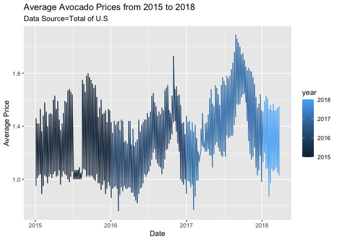

```r
total_us_plot <- ggplot(data = avocado_us, mapping = aes(x =Date, y =AveragePrice, color =year)) +
  geom_line() +
  labs(title = "Average Avocado Prices from 2015 to 2018", subtitle = "Data Source=Total of U.S", x = "Date", y = "Average Price")
total_us_plot
```

```
## geom_path: Each group consists of only one observation. Do you need to adjust
## the group aesthetic?
## geom_path: Each group consists of only one observation. Do you need to adjust
## the group aesthetic?
```

[figure not shown]

```r
total_us_plot + transition_reveal(Date)
```

My friend should note the flucuation of prices through the years.

Avocado Prices for US Regions Plot - date, average price, total volume

[figure not shown]

```r
price_region_plot <- ggplot(data = avocado_regions, mapping = aes(x = Date, y = AveragePrice, color = `Total Volume`)) +
  geom_point() +
  labs(title = "Average Avocado Prices from 2015 to 2018 with respect to volume", subtitle = "Data Source=Regions", x = "Date", y = "Average Price") + transition_time(Date)
price_region_plot
```

Volume is higher when the average price is lower.

Avocado Prices for Each US City

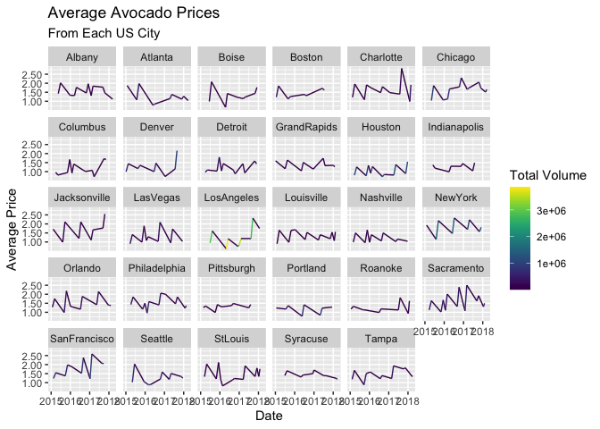

```r
price_city_plot <- ggplot(data = avocado_cities, mapping = aes(x = Date, y = AveragePrice, color = `Total Volume`)) +
  geom_line() +
  facet_wrap(~region) +
  labs(title = "Average Avocado Prices", subtitle = "From Each US City", x = "Date", y = "Average Price")+
  scale_color_viridis(discrete = FALSE) + scale_y_continuous(labels = comma)

price_city_plot
```

```r
states <- sf::st_as_sf(map("state", plot = FALSE, fill = TRUE))
```

```r
citiesbyvolume <- avocado_cities %>%
  arrange(desc(`Total Volume`))
head(citiesbyvolume)
```

```
## # A tibble: 6 × 14
##    ...1 Date       AveragePrice `Total Volume` `4046` `4225` `4770` `Total Bags`
##   <dbl> <date>            <dbl>          <dbl>  <dbl>  <dbl>  <dbl>        <dbl>
## 1    34 2016-05-01         0.62       3863314. 1.36e6 1.05e6 9.86e4     1360962.
## 2    52 2017-01-01         0.84       3551337. 1.22e6 8.30e5 5.68e4     1441332.
## 3    26 2015-06-28         0.94       2921149. 2.07e6 4.19e5 7.58e4      353113.
## 4    20 2017-08-13         1.19       2832850. 1.41e6 4.53e5 1.21e5      846737.
## 5     2 2016-12-11         0.75       2793918. 9.17e5 6.31e5 5.96e4     1186206.
## 6    21 2015-08-02         1.14       1458723. 2.18e4 1.18e6 1.33e3      251358.
## # … with 6 more variables: `Small Bags` <dbl>, `Large Bags` <dbl>,
## #   `XLarge Bags` <dbl>, type <chr>, year <dbl>, region <chr>
```

```r
library(plyr)
library(magrittr)
```

Option 3: Analyze Stock Prices Couldn’t get geometry added to the regions in the avocado data, nor with population for option 2.

```r
avocado_stock <- tq_get(c("CVGW", "AVO"), get = "stock.prices", from = today()-years(2), to = today())
head(avocado_stock)
```

```
## # A tibble: 6 × 8
##   symbol date        open  high   low close volume adjusted
##   <chr>  <date>     <dbl> <dbl> <dbl> <dbl>  <dbl>    <dbl>
## 1 CVGW   2020-11-30  72.6  72.6  71.4  71.6  65500     69.1
## 2 CVGW   2020-12-01  72.2  72.5  70.7  71.7  82700     69.1
## 3 CVGW   2020-12-02  71.9  72.5  70.3  70.8  51500     68.3
## 4 CVGW   2020-12-03  70.6  72.3  70.6  71.2  57200     68.7
## 5 CVGW   2020-12-04  72.0  72.2  70.9  71.4  39700     68.9
## 6 CVGW   2020-12-07  71.3  72.3  70.6  71.4  52600     68.9
```

```r
avocado_stock_plot <- avocado_stock %>%
  select(symbol, date, adjusted) %>%
  pivot_wider(names_from = symbol, values_from = adjusted) %>%
  tk_xts(date_var = date)
head(avocado_stock_plot)
```

```
##                CVGW   AVO
## 2020-11-30 69.09941 13.45
## 2020-12-01 69.12836 13.60
## 2020-12-02 68.26015 13.46
## 2020-12-03 68.69425 13.37
## 2020-12-04 68.89683 13.63
## 2020-12-07 68.85824 13.68
```

Stock Price Visualization

```r
dygraph(avocado_stock_plot, main = "Stock Price Comparison for Calavo Growers VS Mission Produce") %>%
  dyRebase(percent = TRUE) %>%
  dyShading(from = today()-years(2), to = today()) %>%
  dyRangeSelector()
```

[interactive chart not shown]

The success of a product farm company is completed determined by whatever zeitgeist there may be surrounding a certain company and their ability to market their product effectively. As for the product itself, it’s quality will be represented in any product farm company’s stock performance, as noted above when both companies took a dip in the beginning of 2022 that they are still climbing back from. This is likely due to inflation.